# Is Belgium Travelling Enough?

Author

Sheeba Moghal

## How do Movements Work?

A intriguing aspect of the financial dynamics of the Eurozone is the movement of euro coins across borders, especially between Belgium, France, and Germany. Since these three nations have some of the biggest economies in the Eurozone, there is a lot of cross-border trade in products and people, which naturally promotes the circulation of euro coins [1]. Due to the significant amount of trade and tourism that occurs between Germany and its neighbours, France and Belgium, are common places to find German euro coins, which are easily recognised by their unique national designs. Likewise, one can frequently find French and Belgium euros in Germany, each with their own distinctive national emblems [2]. The shared currency facilitates this circulation and makes cross-border financial transactions easy. European individuals from France, Germany, and Belgium were surveyed by the Euro Spatial Diffussion Observatory (EDSO) database about the number of coins in their wallets, the country of minting each coin, and several socioeconomic topics. socioeconomic inquiries about age, sex, occupation, and household size to understand the movement [3].

In terms of tracking the movement of the coins between Domestic and Non-Domestic countries should be proceeded with caution as there could be varying economic distributions, difference in Monetary policies, Cultural and Behavorial factors, Exchange Rate fluctuations, etc, thus showcasing the importance of garnering more information on a macroeconomic scale whilst making these comparisons.

## Coincidal Journeys

As we understand, each coin is a piece of history and national identity for those that use it. May it be in terms of the coin they use or wherever it is minted in. Though these coins traverse borders revealing the underlying dynamics of trade, monetary policy, and international relations, they can also give us the socio-demographic information of who use it.

Figure 1 in the graph showcases that France holds the most coins in comparison to Belgium and Germany, thus holding more coins of other European Countries too. It can be attributed to the central position of France at the European Union and its status as a major tourist destination and due to it’s extensive relationships with other countries. Additionally, tourism is also an important aspect of the French Economy which is greater than Germany and Belgium, in additional to it’s central georgraphic position [4]

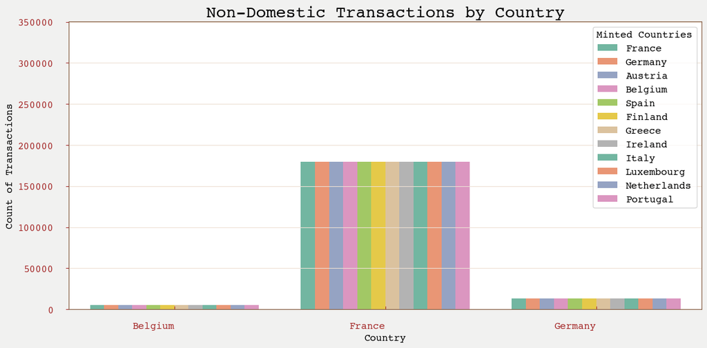

Figure 1: This also about the Non-Domestic transactions on basis of the Domestic Country. France is shown to hold most Non-Domestic Transactions, with varied economic and socio-developmental aspects such as the size of the economy, the geopolitical position, and the geographical location. It is followed by Germany and then Belgium.

In terms of Gender shown in Figure 2, we see that there is almost equal distribution of the denominations when it comes to few demoninations and greater disparity when it comes to the lowest distributions such as 1 cent, 2 cents and 5 cents. This is interesting to look it as the patterns of usage could play an important role as well, as lower denominations due to the rising inflation and costs are used less frequently [5].

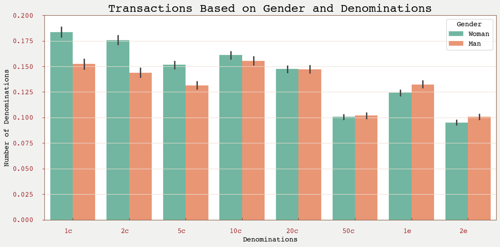

Figure 2: On basis of the transactions based on Gender and the Denominations, we see that there is more disparity within the smaller denominations than the larger denominations. This can be accounted to role of women accounting for more transactions, amongst other reasons.

## Tracing Coin Trails

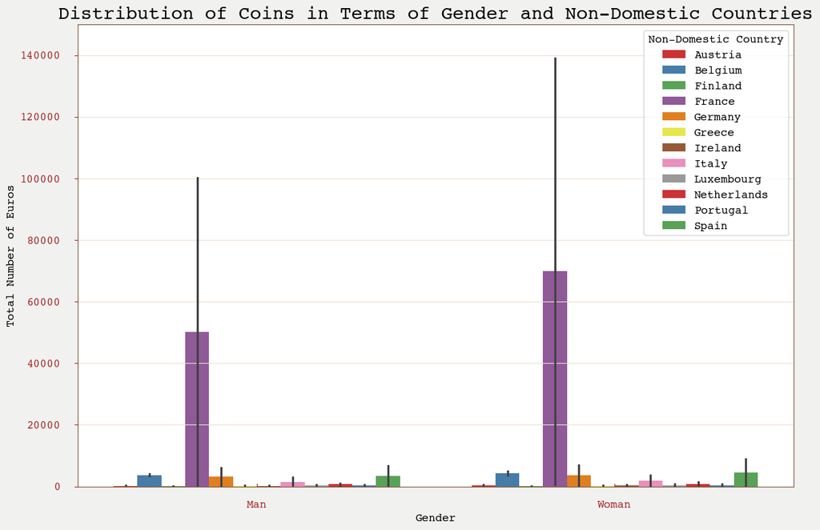

Figure 3: In terms of the distribution of coins in terms of Gender again and keeping in mind the non-domestic countries, we see that Women held most non-domestic euros than Men, yet this was the most again in terms of France.

Additionally, trying to understand the relationship between the country the coins are circulating in and the country it was originally minted at, we again see that France has more coins of itself than Belgium does, as shown in Figure 4. This could be due to the greater population of France than Belgium, tourism, and greater geogaphical proximity of France and a stronger economic position of France in comparison.

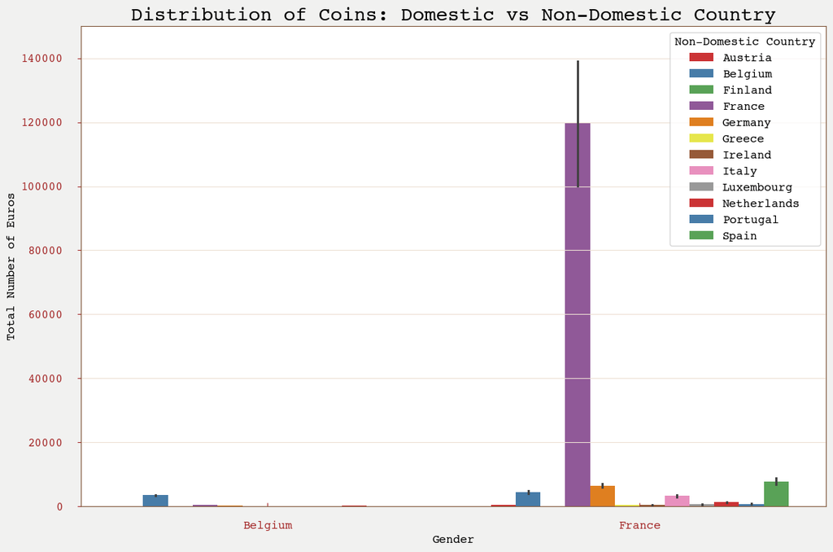

Figure 4: The overall distributions of coins in terms of the Domestic and Non-Domestic Country again highlights that it is indeed France that holds the most coins of itself in terms of Belgium and France.

## Clinking Through Belgium Houses

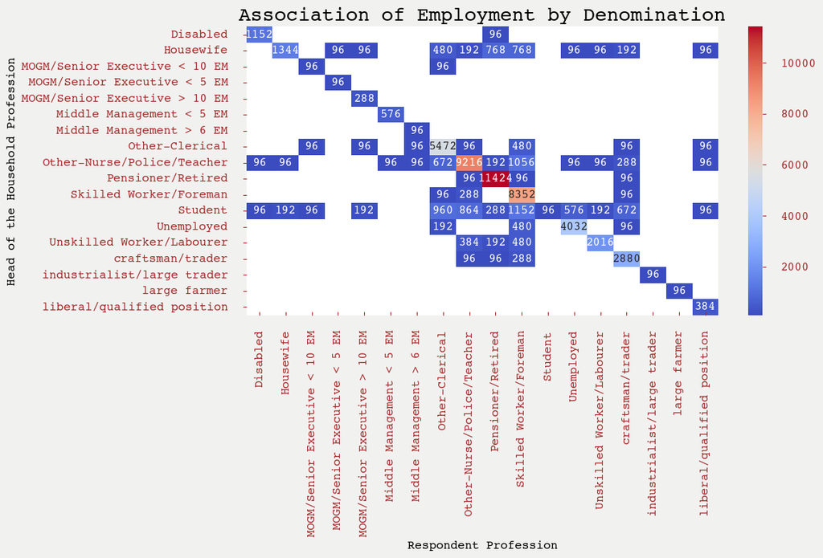

Figure 5: In this aspect, the focus was emphasised more on understanding if the Household Profession and the Respondant’s profession played a role in Denomination. Higher denominations were mainly held by those having the same position. This showcases either that the respondant and the head of the household are the same, or that there is association between profession and the denomination.

## What do we think?

Therefore, whilst tracking the movement of the coins across the Eurozone, it must be proceeded with caution as there are other nuanced aspects to consider, such as the state of the economy, spending patterns of its citizens, socio-economic factors of the country, the Central Bank’s preference in terms of coins, the cross-border networks, etc. Hence, although the small-scale transactions and the social factors play an important role, there are other important factors to consider whilst comparing economies.

## References

[1] https://www.sciencedirect.com/science/article/pii/S1703494915303595?casa_token=gVw8GM7OXQEAAAAA:9Ux5TqsjDltGlrTp2D0sBOn43kw7MAxP2zwiTNeqItYhq2-qvDuRqZR5zPxacqCf1uqNK1IORQ

[2] https://www.tandfonline.com/doi/full/10.1080/09644008.2021.2002847?casa_token=ZqM1uRmQno0AAAAA%3ATYA8ZejJPh6NIBY5INU4M5qAHniyVm65URxjL6myYfhHqcw35hwRthQRuhwt5v3kQTOJf-8xpzSZ

[3] Le Texier, M., Grasland, C., Guérin-Pace, F., & Garnier, B. (2021). Monitoring the distribution of euro coins across borders (2002-2010): A dataset on the contents of 22,500 European citizens’ wallet. Data in brief, 36, 107081. https://doi.org/10.1016/j.dib.2021.107081

[4] https://dl.acm.org/doi/abs/10.1145/3157754.3157761?casa_token=axQQVAUtwcsAAAAA:MFw_HvjnuI8G_I9VGBwI1S5MwwFleDjVT0lUtnW_a_kj_bojFK01KgDdaGJek_Ta6r39JY8FXtjI

[5] https://www.tandfonline.com/doi/abs/10.1080/13511610.2013.864229

[7] https://journals.sagepub.com/doi/abs/10.1177/2031952519864196